# Telecom Customer Churn - Data Exploration

**Project:** COMP 9130 - Mini Project 2: Classification Challenge  
**Dataset:** Telecom Customer Churn  
**Objective:** Predict which customers will leave (churn)

1. Import Libraries
2. Load Dataset
3. Initial Data Inspection
4. Target Variable Analysis
5. Missing Values Analysis
6. Feature Analysis
7. Correlation Analysis
8. Outlier Detection
9. Key Insights Summary

## 1. Import Libraries

```python
# Data manipulation
import pandas as pd
import numpy as np

# Visualization
import matplotlib.pyplot as plt
import seaborn as sns

# Statistical analysis
from scipy import stats

# Settings
import warnings
warnings.filterwarnings('ignore')

# Display settings
pd.set_option('display.max_columns', None)
pd.set_option('display.max_rows', 100)
plt.style.use('seaborn-v0_8-darkgrid')
sns.set_palette('husl')

# Set random seed for reproducibility
np.random.seed(42)

print("Libraries imported successfully!")
```

```
Libraries imported successfully!
```

## 2. Load Dataset

**Dataset Information:**

- **Source:** Telco Customer Churn (Kaggle)
- **Size:** 7,043 samples
- **Features:** 20 (demographics, services, charges, tenure)
- **Target:** Binary (Yes/No churn)
- **Expected Imbalance:** ~27% churn, 73% stay

```python
# Load the dataset
# Note: Update the path to where you've saved the dataset
df = pd.read_csv('../data/WA_Fn-UseC_-Telco-Customer-Churn.csv')

print(f"Dataset loaded successfully!")
print(f"Shape: {df.shape}")
print(f"\nRows: {df.shape[0]:,}")
print(f"Columns: {df.shape[1]}")
```

```
Dataset loaded successfully!
Shape: (7043, 21)

Rows: 7,043
Columns: 21
```

## 3. Initial Data Inspection

```python
# First few rows
print("First 5 rows of the dataset:")
df.head()
```

```
First 5 rows of the dataset:
```

|  | customerID | gender | SeniorCitizen | Partner | Dependents | tenure | PhoneService | MultipleLines | InternetService | OnlineSecurity | OnlineBackup | DeviceProtection | TechSupport | StreamingTV | StreamingMovies | Contract | PaperlessBilling | PaymentMethod | MonthlyCharges | TotalCharges | Churn |
| --- | --- | --- | --- | --- | --- | --- | --- | --- | --- | --- | --- | --- | --- | --- | --- | --- | --- | --- | --- | --- | --- |
| 0 | 7590-VHVEG | Female | 0 | Yes | No | 1 | No | No phone service | DSL | No | Yes | No | No | No | No | Month-to-month | Yes | Electronic check | 29.85 | 29.85 | No |
| 1 | 5575-GNVDE | Male | 0 | No | No | 34 | Yes | No | DSL | Yes | No | Yes | No | No | No | One year | No | Mailed check | 56.95 | 1889.5 | No |
| 2 | 3668-QPYBK | Male | 0 | No | No | 2 | Yes | No | DSL | Yes | Yes | No | No | No | No | Month-to-month | Yes | Mailed check | 53.85 | 108.15 | Yes |
| 3 | 7795-CFOCW | Male | 0 | No | No | 45 | No | No phone service | DSL | Yes | No | Yes | Yes | No | No | One year | No | Bank transfer (automatic) | 42.30 | 1840.75 | No |
| 4 | 9237-HQITU | Female | 0 | No | No | 2 | Yes | No | Fiber optic | No | No | No | No | No | No | Month-to-month | Yes | Electronic check | 70.70 | 151.65 | Yes |

```python
# Dataset info
print("Dataset Information:")
df.info()
```

```
Dataset Information:
<class 'pandas.core.frame.DataFrame'>
RangeIndex: 7043 entries, 0 to 7042
Data columns (total 21 columns):
 #   Column            Non-Null Count  Dtype
---  ------            --------------  -----
 0   customerID        7043 non-null   object
 1   gender            7043 non-null   object
 2   SeniorCitizen     7043 non-null   int64
 3   Partner           7043 non-null   object
 4   Dependents        7043 non-null   object
 5   tenure            7043 non-null   int64
 6   PhoneService      7043 non-null   object
 7   MultipleLines     7043 non-null   object
 8   InternetService   7043 non-null   object
 9   OnlineSecurity    7043 non-null   object
 10  OnlineBackup      7043 non-null   object
 11  DeviceProtection  7043 non-null   object
 12  TechSupport       7043 non-null   object
 13  StreamingTV       7043 non-null   object
 14  StreamingMovies   7043 non-null   object
 15  Contract          7043 non-null   object
 16  PaperlessBilling  7043 non-null   object
 17  PaymentMethod     7043 non-null   object
 18  MonthlyCharges    7043 non-null   float64
 19  TotalCharges      7043 non-null   object
 20  Churn             7043 non-null   object
dtypes: float64(1), int64(2), object(18)
memory usage: 1.1+ MB
```

```python
# Statistical summary
print("Statistical Summary of Numerical Features:")
df.describe()
```

```
Statistical Summary of Numerical Features:
```

|  | SeniorCitizen | tenure | MonthlyCharges |
| --- | --- | --- | --- |
| count | 7043.000000 | 7043.000000 | 7043.000000 |
| mean | 0.162147 | 32.371149 | 64.761692 |
| std | 0.368612 | 24.559481 | 30.090047 |
| min | 0.000000 | 0.000000 | 18.250000 |
| 25% | 0.000000 | 9.000000 | 35.500000 |
| 50% | 0.000000 | 29.000000 | 70.350000 |
| 75% | 0.000000 | 55.000000 | 89.850000 |
| max | 1.000000 | 72.000000 | 118.750000 |

```python
print(f"Dataset shape: {df.shape[0]} rows, {df.shape[1]} columns")
```

```
Dataset shape: 7043 rows, 21 columns
```

```python
# Identify feature types
numerical_features = df.select_dtypes(include=['int64', 'float64']).columns.tolist()
categorical_features = df.select_dtypes(include=['object']).columns.tolist()

# Remove target variable from categorical features if present
if 'Churn' in categorical_features:
    categorical_features.remove('Churn')

# Remove customerID if present
if 'customerID' in categorical_features:
    categorical_features.remove('customerID')

print(f"Numerical Features ({len(numerical_features)}): {numerical_features}")
print(f"\nCategorical Features ({len(categorical_features)}): {categorical_features}")
```

```
Numerical Features (3): ['SeniorCitizen', 'tenure', 'MonthlyCharges']

Categorical Features (16): ['gender', 'Partner', 'Dependents', 'PhoneService', 'MultipleLines', 'InternetService', 'OnlineSecurity', 'OnlineBackup', 'DeviceProtection', 'TechSupport', 'StreamingTV', 'StreamingMovies', 'Contract', 'PaperlessBilling', 'PaymentMethod', 'TotalCharges']
```

## 4. Target Variable Analysis

**Critical for Classification:** Understanding class distribution helps us:

- Detect class imbalance
- Choose appropriate evaluation metrics
- Decide on imbalance handling strategies

```python
# Target variable distribution
print("Target Variable: Churn")
print("=" * 50)
churn_counts = df['Churn'].value_counts()
churn_percentages = df['Churn'].value_counts(normalize=True) * 100

target_summary = pd.DataFrame({
    'Count': churn_counts,
    'Percentage': churn_percentages
})

print(target_summary)
print("\n" + "=" * 50)

# Calculate imbalance ratio
minority_class = churn_counts.min()
majority_class = churn_counts.max()
imbalance_ratio = majority_class / minority_class

print(f"\nImbalance Ratio: {imbalance_ratio:.2f}:1")
print(f"Minority Class Size: {minority_class:,} ({churn_percentages.min():.2f}%)")
print(f"Majority Class Size: {majority_class:,} ({churn_percentages.max():.2f}%)")

# Determine if imbalanced
minority_percentage = churn_percentages.min()
if minority_percentage < 40 or minority_percentage > 60:
    print(f"\n⚠️  IMBALANCED DATASET DETECTED!")
    print(f"   We need to apply imbalance handling techniques.")
else:
    print(f"\n✓ Dataset is relatively balanced.")
```

```
Target Variable: Churn
==================================================
       Count  Percentage
Churn
No      5174   73.463013
Yes     1869   26.536987

==================================================

Imbalance Ratio: 2.77:1
Minority Class Size: 1,869 (26.54%)
Majority Class Size: 5,174 (73.46%)

⚠️  IMBALANCED DATASET DETECTED!
   We need to apply imbalance handling techniques.
```

The dataset is imbalanced (~27% churn, ~73% non-churn), therefore accuracy alone is misleading.

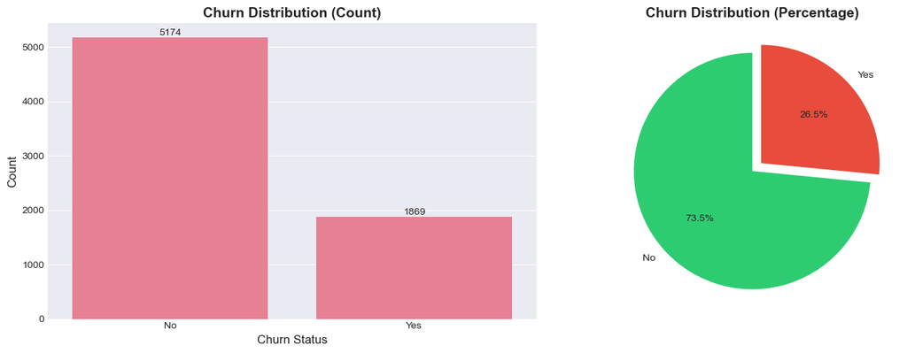

```
📊 Interpretation:
   - The dataset is IMBALANCED with approximately 73% non-churn and 27% churn.
   - We should NOT use accuracy as the primary metric.
   - We should use F1-score, ROC-AUC, or precision-recall metrics instead.
   - We'll need to handle this imbalance in the modeling phase.
```

```python
# Visualize target distribution
fig, axes = plt.subplots(1, 2, figsize=(14, 5))

# Count plot
sns.countplot(data=df, x='Churn', ax=axes[0])
axes[0].set_title('Churn Distribution (Count)', fontsize=14, fontweight='bold')
axes[0].set_xlabel('Churn Status', fontsize=12)
axes[0].set_ylabel('Count', fontsize=12)

# Add value labels on bars
for container in axes[0].containers:
    axes[0].bar_label(container, fmt='%d')

# Pie chart
colors = ['#2ecc71', '#e74c3c']  # Green for No, Red for Yes
axes[1].pie(churn_counts, labels=churn_counts.index, autopct='%1.1f%%',
            startangle=90, colors=colors, explode=(0, 0.1))
axes[1].set_title('Churn Distribution (Percentage)', fontsize=14, fontweight='bold')

plt.tight_layout()
plt.show()

print("\n📊 Interpretation:")
print("   - The dataset is IMBALANCED with approximately 73% non-churn and 27% churn.")
print("   - We should NOT use accuracy as the primary metric.")
print("   - We should use F1-score, ROC-AUC, or precision-recall metrics instead.")
print("   - We'll need to handle this imbalance in the modeling phase.")
```

## 5. Missing Values Analysis

```python
# Check for missing values
missing_values = df.isnull().sum()
missing_percentage = (df.isnull().sum() / len(df)) * 100

missing_df = pd.DataFrame({
    'Missing_Count': missing_values,
    'Percentage': missing_percentage
})

missing_df = missing_df[missing_df['Missing_Count'] > 0].sort_values('Missing_Count', ascending=False)

if len(missing_df) > 0:
    print("Missing Values Found:")
    print("=" * 50)
    print(missing_df)

    # Visualize missing values
    plt.figure(figsize=(10, 6))
    missing_df['Percentage'].plot(kind='barh')
    plt.xlabel('Percentage of Missing Values')
    plt.title('Missing Values by Feature')
    plt.tight_layout()
    plt.show()
else:
    print("✓ No missing values found in the dataset!")
```

```
✓ No missing values found in the dataset!
```

```python
# Check for potential hidden missing values (empty strings, whitespace, etc.)
print("Checking for hidden missing values (empty strings, whitespace, etc.)...")
print("=" * 50)

for col in df.columns:
    if df[col].dtype == 'object':
        # Check for empty strings or whitespace
        empty_count = (df[col].str.strip() == '').sum()
        whitespace_count = (df[col].str.isspace()).sum()

        if empty_count > 0 or whitespace_count > 0:
            print(f"{col}: {empty_count} empty strings, {whitespace_count} whitespace-only values")

print("\nCheck complete.")
```

```
Checking for hidden missing values (empty strings, whitespace, etc.)...
==================================================
TotalCharges: 11 empty strings, 11 whitespace-only values

Check complete.
```

## 6. Feature Analysis

### 6.1 Numerical Features

```
Analyzing 3 numerical features...
```

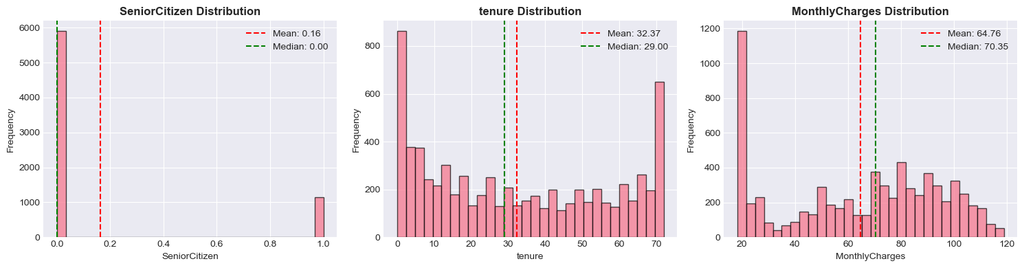

```python
# Distribution of numerical features
print(f"Analyzing {len(numerical_features)} numerical features...")

# Create subplots for all numerical features
n_features = len(numerical_features)
n_cols = 3
n_rows = (n_features + n_cols - 1) // n_cols

fig, axes = plt.subplots(n_rows, n_cols, figsize=(15, n_rows * 4))
axes = axes.flatten() if n_features > 1 else [axes]

for idx, feature in enumerate(numerical_features):
    # Histogram with KDE
    axes[idx].hist(df[feature].dropna(), bins=30, edgecolor='black', alpha=0.7)
    axes[idx].set_title(f'{feature} Distribution', fontweight='bold')
    axes[idx].set_xlabel(feature)
    axes[idx].set_ylabel('Frequency')

    # Add mean and median lines
    mean_val = df[feature].mean()
    median_val = df[feature].median()
    axes[idx].axvline(mean_val, color='red', linestyle='--', label=f'Mean: {mean_val:.2f}')
    axes[idx].axvline(median_val, color='green', linestyle='--', label=f'Median: {median_val:.2f}')
    axes[idx].legend()

# Hide extra subplots
for idx in range(n_features, len(axes)):
    axes[idx].set_visible(False)

plt.tight_layout()
plt.show()
```

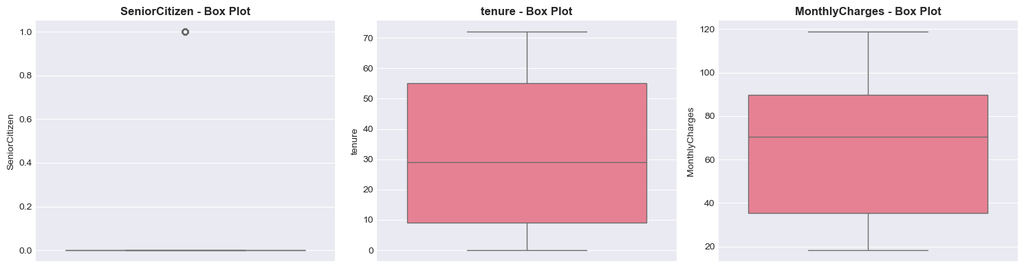

```python
# Box plots to identify outliers in numerical features
fig, axes = plt.subplots(n_rows, n_cols, figsize=(15, n_rows * 4))
axes = axes.flatten() if n_features > 1 else [axes]

for idx, feature in enumerate(numerical_features):
    sns.boxplot(data=df, y=feature, ax=axes[idx])
    axes[idx].set_title(f'{feature} - Box Plot', fontweight='bold')
    axes[idx].set_ylabel(feature)

# Hide extra subplots
for idx in range(n_features, len(axes)):
    axes[idx].set_visible(False)

plt.tight_layout()
plt.show()
```

### 6.2 Numerical Features by Churn Status

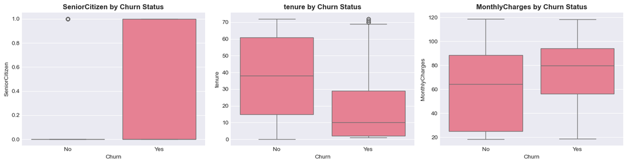

```
📊 Look for features where churned and non-churned customers show different distributions.
   These features will be important for our classification model.
```

```python
# Compare numerical features between churned and non-churned customers
fig, axes = plt.subplots(n_rows, n_cols, figsize=(15, n_rows * 4))
axes = axes.flatten() if n_features > 1 else [axes]

for idx, feature in enumerate(numerical_features):
    # Box plot by churn status
    sns.boxplot(data=df, x='Churn', y=feature, ax=axes[idx])
    axes[idx].set_title(f'{feature} by Churn Status', fontweight='bold')
    axes[idx].set_xlabel('Churn')
    axes[idx].set_ylabel(feature)

# Hide extra subplots
for idx in range(n_features, len(axes)):
    axes[idx].set_visible(False)

plt.tight_layout()
plt.show()

print("📊 Look for features where churned and non-churned customers show different distributions.")
print("   These features will be important for our classification model.")
```

### 6.3 Categorical Features

```python
# Examine categorical features
print(f"Analyzing {len(categorical_features)} categorical features...\n")

for feature in categorical_features:
    print(f"\n{feature}:")
    print("-" * 50)
    value_counts = df[feature].value_counts()
    print(value_counts)
    print(f"Unique values: {df[feature].nunique()}")
```

```
Analyzing 16 categorical features...


gender:
--------------------------------------------------
gender
Male      3555
Female    3488
Name: count, dtype: int64
Unique values: 2

Partner:
--------------------------------------------------
Partner
No     3641
Yes    3402
Name: count, dtype: int64
Unique values: 2

Dependents:
--------------------------------------------------
Dependents
No     4933
Yes    2110
Name: count, dtype: int64
Unique values: 2

PhoneService:
--------------------------------------------------
PhoneService
Yes    6361
No      682
Name: count, dtype: int64
Unique values: 2

MultipleLines:
--------------------------------------------------
MultipleLines
No                  3390
Yes                 2971
```

[output cut: 95 more lines]

```
--------------------------------------------------
TotalCharges
          11
20.2      11
19.75      9
20.05      8
19.9       8
          ..
6849.4     1
692.35     1
130.15     1
3211.9     1
6844.5     1
Name: count, Length: 6531, dtype: int64
Unique values: 6531
```

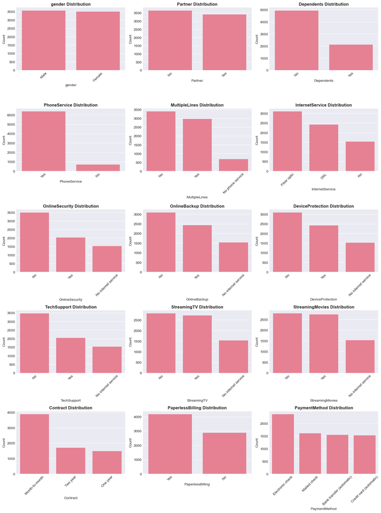

```python
# Visualize categorical features (top features with fewer unique values)
# Select features with reasonable number of categories for visualization
viz_features = [f for f in categorical_features if df[f].nunique() <= 10]

if len(viz_features) > 0:
    n_viz = len(viz_features)
    n_cols_cat = 3
    n_rows_cat = (n_viz + n_cols_cat - 1) // n_cols_cat

    fig, axes = plt.subplots(n_rows_cat, n_cols_cat, figsize=(15, n_rows_cat * 4))
    axes = axes.flatten() if n_viz > 1 else [axes]

    for idx, feature in enumerate(viz_features):
        sns.countplot(data=df, x=feature, ax=axes[idx], order=df[feature].value_counts().index)
        axes[idx].set_title(f'{feature} Distribution', fontweight='bold')
        axes[idx].set_xlabel(feature)
        axes[idx].set_ylabel('Count')
        axes[idx].tick_params(axis='x', rotation=45)

    # Hide extra subplots
    for idx in range(n_viz, len(axes)):
        axes[idx].set_visible(False)

    plt.tight_layout()
    plt.show()
```

### 6.4 Categorical Features by Churn Status

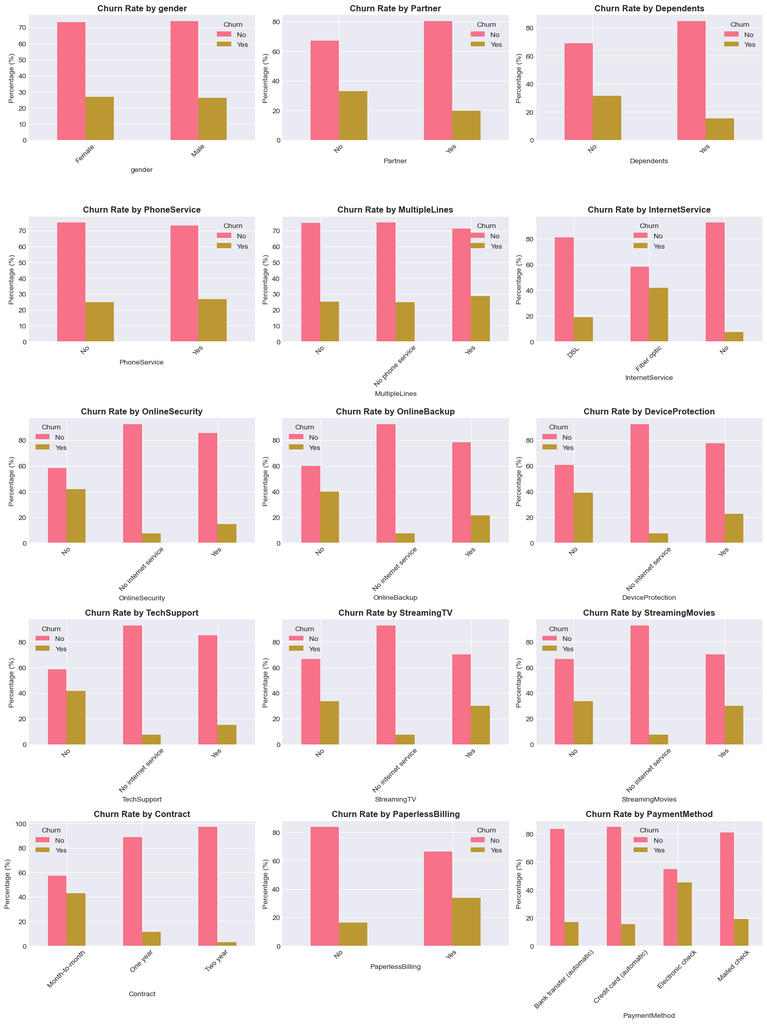

```
📊 Look for categories with significantly higher churn rates.
   These are strong predictive features for our model.
```

```python
# Analyze churn rate by categorical features
if len(viz_features) > 0:
    fig, axes = plt.subplots(n_rows_cat, n_cols_cat, figsize=(15, n_rows_cat * 4))
    axes = axes.flatten() if n_viz > 1 else [axes]

    for idx, feature in enumerate(viz_features):
        # Create a cross-tabulation
        ct = pd.crosstab(df[feature], df['Churn'], normalize='index') * 100
        ct.plot(kind='bar', ax=axes[idx], stacked=False)
        axes[idx].set_title(f'Churn Rate by {feature}', fontweight='bold')
        axes[idx].set_xlabel(feature)
        axes[idx].set_ylabel('Percentage (%)')
        axes[idx].legend(title='Churn', labels=['No', 'Yes'])
        axes[idx].tick_params(axis='x', rotation=45)

    # Hide extra subplots
    for idx in range(n_viz, len(axes)):
        axes[idx].set_visible(False)

    plt.tight_layout()
    plt.show()

print("📊 Look for categories with significantly higher churn rates.")
print("   These are strong predictive features for our model.")
```

## 7. Correlation Analysis

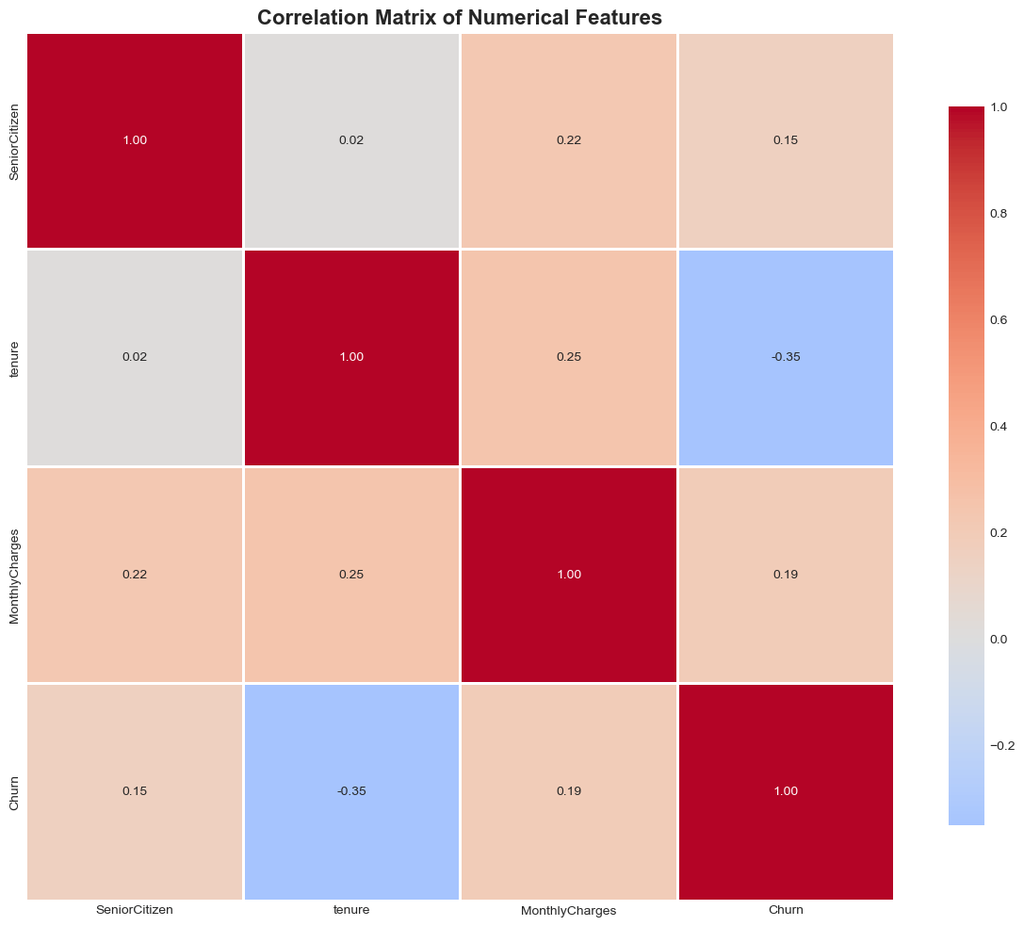

```python
# Create a copy of the dataframe for correlation analysis
df_corr = df.copy()

# Convert binary target to numeric (if it's Yes/No)
if df_corr['Churn'].dtype == 'object':
    df_corr['Churn'] = df_corr['Churn'].map({'No': 0, 'Yes': 1})

# Select only numerical columns for correlation
numerical_df = df_corr.select_dtypes(include=['int64', 'float64'])

# Calculate correlation matrix
correlation_matrix = numerical_df.corr()

# Visualize correlation matrix
plt.figure(figsize=(12, 10))
sns.heatmap(correlation_matrix, annot=True, fmt='.2f', cmap='coolwarm',
            center=0, square=True, linewidths=1, cbar_kws={"shrink": 0.8})
plt.title('Correlation Matrix of Numerical Features', fontsize=16, fontweight='bold')
plt.tight_layout()
plt.show()
```

```
Features Correlation with Churn:
==================================================
Churn             1.000000
MonthlyCharges    0.193356
SeniorCitizen     0.150889
tenure           -0.352229
Name: Churn, dtype: float64
```

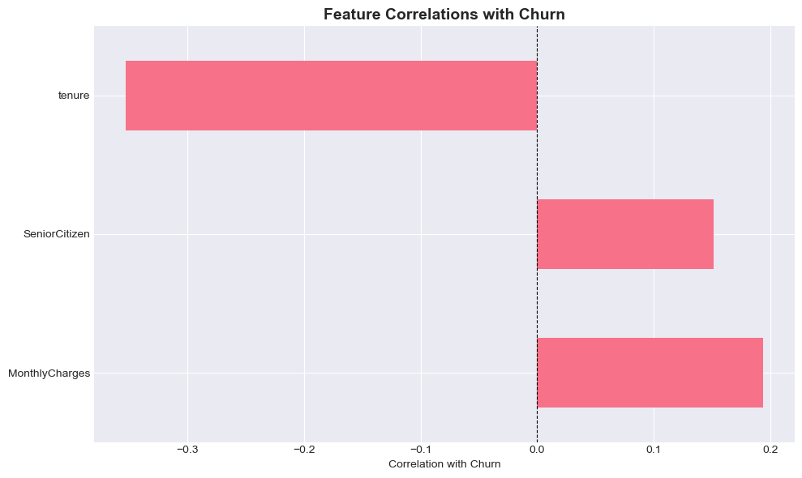

```
📊 Interpretation:
   - Positive correlations: Higher values → More likely to churn
   - Negative correlations: Higher values → Less likely to churn
   - Features with |correlation| > 0.1 are potentially useful predictors
```

```python
# Identify features most correlated with Churn
if 'Churn' in correlation_matrix.columns:
    churn_correlations = correlation_matrix['Churn'].sort_values(ascending=False)

    print("Features Correlation with Churn:")
    print("=" * 50)
    print(churn_correlations)

    # Visualize correlations with target
    plt.figure(figsize=(10, 6))
    churn_correlations.drop('Churn').plot(kind='barh')
    plt.xlabel('Correlation with Churn')
    plt.title('Feature Correlations with Churn', fontsize=14, fontweight='bold')
    plt.axvline(x=0, color='black', linestyle='--', linewidth=0.8)
    plt.tight_layout()
    plt.show()

    print("\n📊 Interpretation:")
    print("   - Positive correlations: Higher values → More likely to churn")
    print("   - Negative correlations: Higher values → Less likely to churn")
    print("   - Features with |correlation| > 0.1 are potentially useful predictors")
```

```python
# Identify highly correlated feature pairs (potential multicollinearity)
print("\nHighly Correlated Feature Pairs (|correlation| > 0.7):")
print("=" * 50)

# Get upper triangle of correlation matrix
upper_triangle = correlation_matrix.where(
    np.triu(np.ones(correlation_matrix.shape), k=1).astype(bool)
)

# Find features with high correlation
high_corr_pairs = []
for column in upper_triangle.columns:
    for index in upper_triangle.index:
        corr_value = upper_triangle.loc[index, column]
        if abs(corr_value) > 0.7:
            high_corr_pairs.append((index, column, corr_value))

if len(high_corr_pairs) > 0:
    for feat1, feat2, corr in high_corr_pairs:
        print(f"{feat1} <-> {feat2}: {corr:.3f}")
    print("\n⚠️  These feature pairs may cause multicollinearity.")
    print("   Consider removing one from each pair or using regularization.")
else:
    print("✓ No highly correlated feature pairs found.")
```

```
Highly Correlated Feature Pairs (|correlation| > 0.7):
==================================================
✓ No highly correlated feature pairs found.
```

## 8. Outlier Detection

```
Outlier Detection using IQR Method:
==================================================
      Feature  Outlier_Count  Percentage  Lower_Bound  Upper_Bound
SeniorCitizen           1142   16.214681          0.0          0.0
```

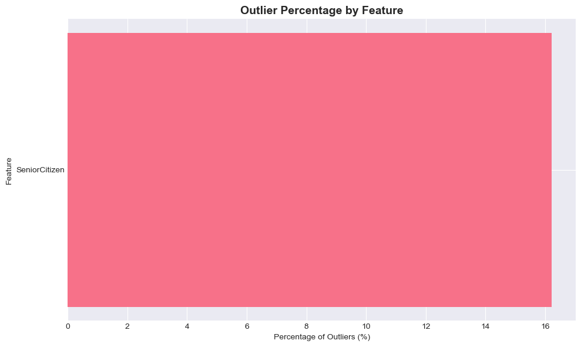

```
⚠️  Outliers detected in some features.
   Decision: Keep outliers for now (they may be legitimate values).
   Tree-based models are robust to outliers.
```

```python
# Detect outliers using IQR method
print("Outlier Detection using IQR Method:")
print("=" * 50)

outlier_summary = []

for feature in numerical_features:
    Q1 = df[feature].quantile(0.25)
    Q3 = df[feature].quantile(0.75)
    IQR = Q3 - Q1

    lower_bound = Q1 - 1.5 * IQR
    upper_bound = Q3 + 1.5 * IQR

    outliers = df[(df[feature] < lower_bound) | (df[feature] > upper_bound)]
    outlier_count = len(outliers)
    outlier_percentage = (outlier_count / len(df)) * 100

    outlier_summary.append({
        'Feature': feature,
        'Outlier_Count': outlier_count,
        'Percentage': outlier_percentage,
        'Lower_Bound': lower_bound,
        'Upper_Bound': upper_bound
    })

outlier_df = pd.DataFrame(outlier_summary)
outlier_df = outlier_df[outlier_df['Outlier_Count'] > 0].sort_values('Outlier_Count', ascending=False)

if len(outlier_df) > 0:
    print(outlier_df.to_string(index=False))

    # Visualize outliers
    plt.figure(figsize=(10, 6))
    plt.barh(outlier_df['Feature'], outlier_df['Percentage'])
    plt.xlabel('Percentage of Outliers (%)')
    plt.ylabel('Feature')
    plt.title('Outlier Percentage by Feature', fontsize=14, fontweight='bold')
    plt.tight_layout()
    plt.show()

    print("\n⚠️  Outliers detected in some features.")
    print("   Decision: Keep outliers for now (they may be legitimate values).")
    print("   Tree-based models are robust to outliers.")
else:
    print("✓ No significant outliers detected.")
```

## 9. Key Insights Summary

```python
print("="*70)
print("KEY INSIGHTS FROM EXPLORATORY DATA ANALYSIS")
print("="*70)

print("\n1. DATASET OVERVIEW:")
print(f"   - Total samples: {len(df):,}")
print(f"   - Total features: {df.shape[1]}")
print(f"   - Numerical features: {len(numerical_features)}")
print(f"   - Categorical features: {len(categorical_features)}")

print("\n2. TARGET VARIABLE (CHURN):")
churn_dist = df['Churn'].value_counts(normalize=True) * 100
print(f"   - Class distribution: {churn_dist.to_dict()}")
print(f"   - Imbalance ratio: {imbalance_ratio:.2f}:1")
print(f"   - ⚠️  IMBALANCED DATASET - Need special handling!")

print("\n3. DATA QUALITY:")
if len(missing_df) > 0:
    print(f"   - Missing values found in {len(missing_df)} features")
    print(f"   - Action required: Imputation or removal")
else:
    print(f"   - ✓ No missing values")

if len(outlier_df) > 0:
    print(f"   - Outliers detected in {len(outlier_df)} features")
    print(f"   - Decision: Keep for now (tree-based models are robust)")
else:
    print(f"   - ✓ No significant outliers")

print("\n4. FEATURE CORRELATIONS:")
if 'Churn' in correlation_matrix.columns:
    top_corr = churn_correlations.drop('Churn').abs().nlargest(3)
    print(f"   - Top 3 features correlated with churn:")
    for feat, corr in top_corr.items():
        print(f"     • {feat}: {correlation_matrix.loc[feat, 'Churn']:.3f}")

if len(high_corr_pairs) > 0:
    print(f"\n   - ⚠️  {len(high_corr_pairs)} highly correlated feature pairs found")
    print(f"   - May need to address multicollinearity")

print("\n5. NEXT STEPS FOR MODELING:")
print("   ✓ Handle class imbalance (SMOTE, class weights, threshold tuning)")
print("   ✓ Encode categorical variables")
print("   ✓ Scale numerical features")
print("   ✓ Use stratified train-test split")
print("   ✓ Choose appropriate metrics (F1, ROC-AUC, NOT accuracy)")
print("   ✓ Train multiple models and compare")

print("\n" + "="*70)
print("EXPLORATION COMPLETE - Ready for Modeling Phase!")
print("="*70)
```

```
======================================================================
KEY INSIGHTS FROM EXPLORATORY DATA ANALYSIS
======================================================================

1. DATASET OVERVIEW:
   - Total samples: 7,043
   - Total features: 21
   - Numerical features: 3
   - Categorical features: 16

2. TARGET VARIABLE (CHURN):
   - Class distribution: {'No': 73.4630129206304, 'Yes': 26.536987079369588}
   - Imbalance ratio: 2.77:1
   - ⚠️  IMBALANCED DATASET - Need special handling!

3. DATA QUALITY:
   - ✓ No missing values
   - Outliers detected in 1 features
   - Decision: Keep for now (tree-based models are robust)

4. FEATURE CORRELATIONS:
   - Top 3 features correlated with churn:
     • tenure: -0.352
     • MonthlyCharges: 0.193
     • SeniorCitizen: 0.151

5. NEXT STEPS FOR MODELING:
   ✓ Handle class imbalance (SMOTE, class weights, threshold tuning)
   ✓ Encode categorical variables
   ✓ Scale numerical features
   ✓ Use stratified train-test split
   ✓ Choose appropriate metrics (F1, ROC-AUC, NOT accuracy)
   ✓ Train multiple models and compare

======================================================================
EXPLORATION COMPLETE - Ready for Modeling Phase!
======================================================================
```

## Conclusion

This exploration notebook has provided comprehensive insights into the Telecom Customer Churn dataset:

**Key Findings:**

1. **Imbalanced Dataset**: ~73% non-churn, ~27% churn - requires special handling
2. **Data Quality**: Generally clean data with minimal issues
3. **Feature Types**: Mix of numerical and categorical features
4. **Predictive Features**: Several features show correlation with churn

**Recommendations for Modeling:**

- Use F1-score or ROC-AUC as primary metrics (NOT accuracy)
- Apply imbalance handling techniques (SMOTE, class weights)
- Use stratified train-test split
- Consider tree-based models (Random Forest, XGBoost) which handle mixed data types well
- Implement proper preprocessing pipeline

Based on the observed class imbalance and feature distributions, special care will be taken during model training using stratified splits and imbalance-handling techniques such as class weighting and SMOTE.

**Next Notebook:** `02_modeling.ipynb` - Build and evaluate classification models